# Capstone Data Selection

2024-01-18

#loading in the required packages

```r
library(ISLR)
library(caret)
library(class)
library(gmodels)
library(tidyverse)
library(factoextra)
library(flexclust)
```

```r
library(cluster)
library(corrplot)
library(ggcorrplot)
library(caret)
library(randomForest)
library(gam)
library(e1071)
library(pROC)
library(reshape2)
library(ggstatsplot)
library(stats)
library(psych)
library(devtools)
library(ggbiplot)
library(openxlsx)
```

#reading in my data

```r
diabetes <- read.csv('diabetes_prediction_dataset.csv')
#is.na(diabetes)
head(diabetes)
```

```
##   gender age hypertension heart_disease smoking_history   bmi HbA1c_level
## 1 Female  80            0             1           never 25.19         6.6
## 2 Female  54            0             0         No Info 27.32         6.6
## 3   Male  28            0             0           never 27.32         5.7
## 4 Female  36            0             0         current 23.45         5.0
## 5   Male  76            1             1         current 20.14         4.8
## 6 Female  20            0             0           never 27.32         6.6
##   blood_glucose_level diabetes
## 1                 140        0
## 2                  80        0
## 3                 158        0
## 4                 155        0
## 5                 155        0
## 6                  85        0
```

#Getting a feel for the dataset I am going to be working with

```r
dim(diabetes)
```

```
## [1] 100000      9
```

```r
str(diabetes)
```

```
## 'data.frame':    100000 obs. of  9 variables:
##  $ gender             : chr  "Female" "Female" "Male" "Female" ...
##  $ age                : num  80 54 28 36 76 20 44 79 42 32 ...
##  $ hypertension       : int  0 0 0 0 1 0 0 0 0 0 ...
##  $ heart_disease      : int  1 0 0 0 1 0 0 0 0 0 ...
##  $ smoking_history    : chr  "never" "No Info" "never" "current" ...
##  $ bmi                : num  25.2 27.3 27.3 23.4 20.1 ...
##  $ HbA1c_level        : num  6.6 6.6 5.7 5 4.8 6.6 6.5 5.7 4.8 5 ...
##  $ blood_glucose_level: int  140 80 158 155 155 85 200 85 145 100 ...
##  $ diabetes           : int  0 0 0 0 0 0 1 0 0 0 ...
```

#summary statistics for each variable

```r
summary(diabetes)
```

```
##     gender               age         hypertension     heart_disease
##  Length:100000      Min.   : 0.08   Min.   :0.00000   Min.   :0.00000
##  Class :character   1st Qu.:24.00   1st Qu.:0.00000   1st Qu.:0.00000
##  Mode  :character   Median :43.00   Median :0.00000   Median :0.00000
##                     Mean   :41.89   Mean   :0.07485   Mean   :0.03942
##                     3rd Qu.:60.00   3rd Qu.:0.00000   3rd Qu.:0.00000
##                     Max.   :80.00   Max.   :1.00000   Max.   :1.00000
##  smoking_history         bmi         HbA1c_level    blood_glucose_level
##  Length:100000      Min.   :10.01   Min.   :3.500   Min.   : 80.0
##  Class :character   1st Qu.:23.63   1st Qu.:4.800   1st Qu.:100.0
##  Mode  :character   Median :27.32   Median :5.800   Median :140.0
##                     Mean   :27.32   Mean   :5.528   Mean   :138.1
##                     3rd Qu.:29.58   3rd Qu.:6.200   3rd Qu.:159.0
##                     Max.   :95.69   Max.   :9.000   Max.   :300.0
##     diabetes
##  Min.   :0.000
##  1st Qu.:0.000
##  Median :0.000
##  Mean   :0.085
##  3rd Qu.:0.000
##  Max.   :1.000
```

#checking for missing values in each variable

```r
missing_counts <- colSums(is.na(diabetes))
print(missing_counts)
```

```
##              gender                 age        hypertension       heart_disease
##                   0                   0                   0                   0
##     smoking_history                 bmi         HbA1c_level blood_glucose_level
##                   0                   0                   0                   0
##            diabetes
##                   0
```

# Create a bar plot to visualize the missing values

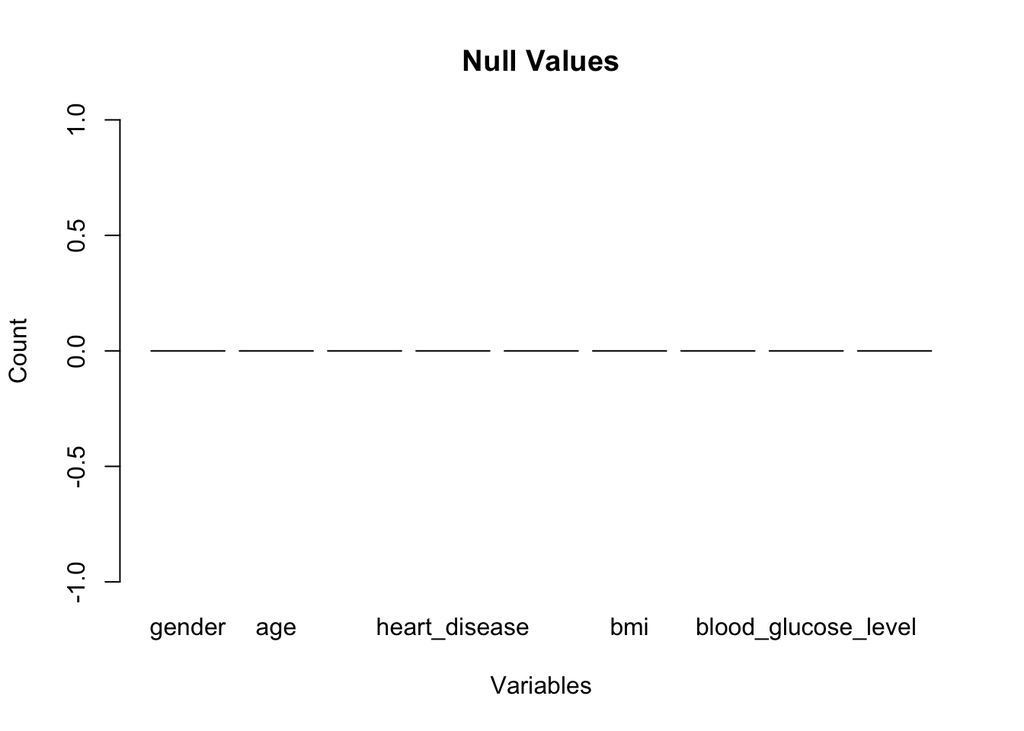

```r
barplot(missing_counts, main = "Null Values", xlab = "Variables", ylab = "Count")
```

#Seperated categorical and numerical variables for descriptive analysis

```r
analyze_categorical <- function(variable) {
freq <- table(variable)
freq_df <- as.data.frame(freq)
colnames(freq_df) <- c("Category", "Count")
freq_df <- freq_df[order(freq_df$Count, decreasing = TRUE), ]
print(freq_df)
}
#Extract categorical variables
categorical_diabetes <- diabetes[, sapply(diabetes, is.character) ]
#Extract numerical variables
numerical_diabetes <- diabetes[, sapply(diabetes, is.numeric) ]
```

#Below is the creation of a visualization of the summary statistics, the each bar represents a summary statistic # 1st:Min , 2nd:1st quart , 3rd:Median , 4th:Mean, 5th:3rd quart , 6th:Max

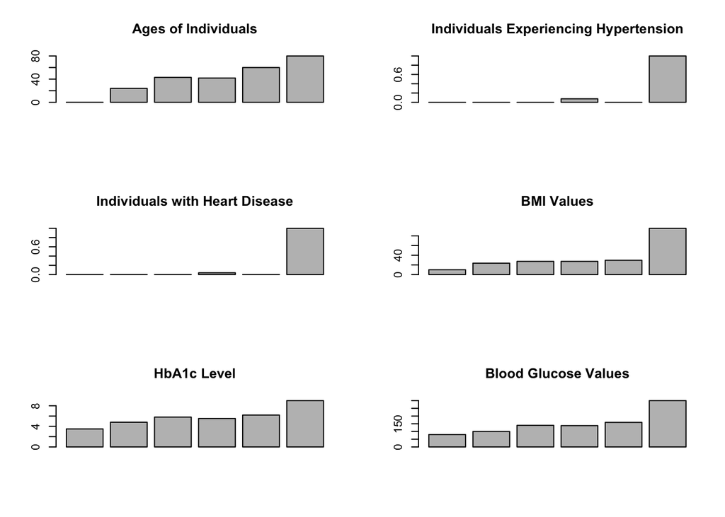

```r
# Descriptive analysis of numeric variables
Age_summary <- summary(diabetes$age)
Hypertension_summary <- summary(diabetes$hypertension)
Heart_disease_summary <- summary(diabetes$heart_disease)
BMI_summary <- summary(diabetes$bmi)
HbA1c_summary <- summary(diabetes$HbA1c_level)
Blood_glucose_level_summary <- summary(diabetes$blood_glucose_level)
Diabetes_summary <- summary(diabetes$diabetes)
# Convert summary statistics into numeric vectors
Age_vals <- as.numeric(Age_summary)
Hypertension_vals <- as.numeric(Hypertension_summary)
Heart_disease_vals <- as.numeric(Heart_disease_summary)
BMI_vals <- as.numeric(BMI_summary)
HbA1c_vals <- as.numeric(HbA1c_summary)
Blood_glucose_vals <- as.numeric(Blood_glucose_level_summary)
Diabetes_vals <- as.numeric(Diabetes_summary)
# Set the layout for the plot grid
par(mfrow = c(3, 2))
# Create individual bar plots for each numeric variable
barplot(Age_vals, main = "Ages of Individuals")
barplot(Hypertension_vals, main = "Individuals Experiencing Hypertension")
barplot(Heart_disease_vals, main = "Individuals with Heart Disease")
barplot(BMI_vals, main = "BMI Values")
barplot(HbA1c_vals, main = "HbA1c Level")
barplot(Blood_glucose_vals, main = "Blood Glucose Values")
```

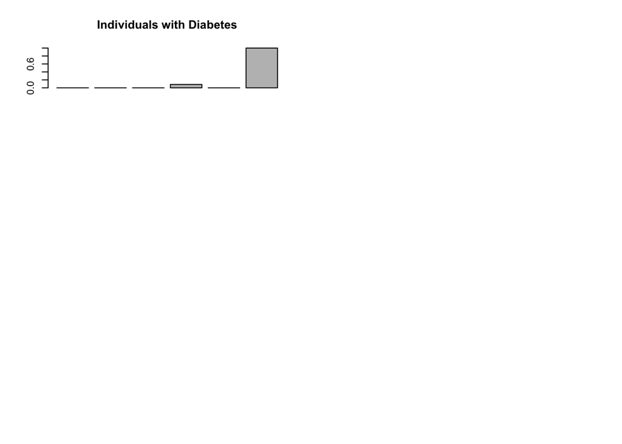

```r
barplot(Diabetes_vals, main = "Individuals with Diabetes")
```

#Boxplots for the numeric variables

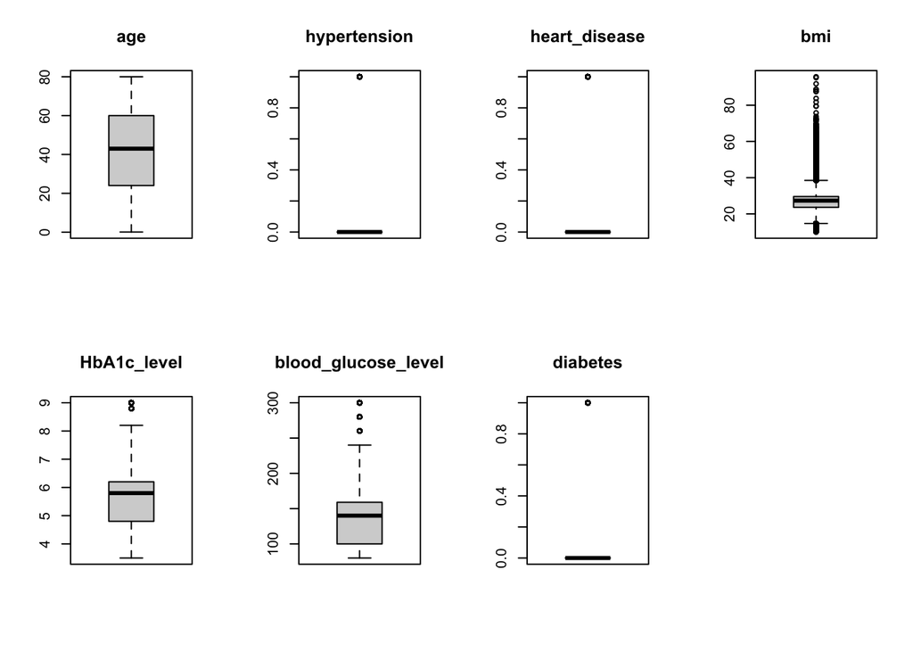

```r
numeric_vars <- c("age", "hypertension", "heart_disease", "bmi", "HbA1c_level", "blood_glucose_level", "diabetes")
# Set the layout for the plot grid
par(mfrow = c(2, 4))
# Create boxplots for each numerical variable
for (var in numeric_vars) {
# Plot the boxplot
boxplot(diabetes[[var]], main = var)
}
```

#Removing outliers from the data #For BMI I removed the values over fifty as they are extremely abnormal values that indicate severe obesity which would effect the model, for HbA1c I chose to remove above an 8.2 because above 8 is associated with having poorly controlled diabetes (I specifically chose 8.2 because If I choose 8 exact it would have cut off a large number of individuals who fit the criteria), for blood glucose I choose above two hundred as any higher is associated directly to being linked with diabetes.

```r
eliminatedBMI <- numerical_diabetes$bmi > 50
cleandiabetes <- subset(numerical_diabetes, !eliminatedBMI)

eliminatedHbA1c <- cleandiabetes$HbA1c_level > 8.2
cleandiabetes <- subset(cleandiabetes, !eliminatedHbA1c)

eliminatedBloodglucose <- cleandiabetes$blood_glucose_level > 201
cleandiabetes <- subset(cleandiabetes, !eliminatedBloodglucose)
```

#nonoutlier data boxplots

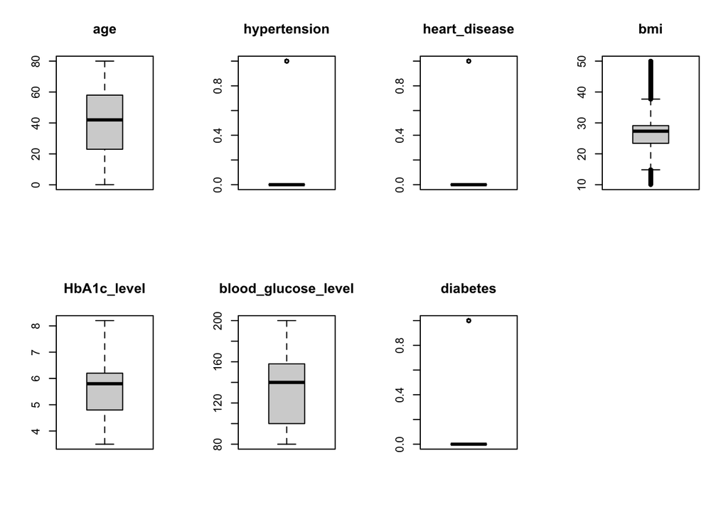

```r
# Set the layout for the plot grid
par(mfrow = c(2, 4))
# Create boxplots for each numerical variable
for (var in numeric_vars) {
# Plot the boxplot
boxplot(cleandiabetes[[var]], main = var)
}
```

#further descriptive analysis, histograms for all the numeric variables

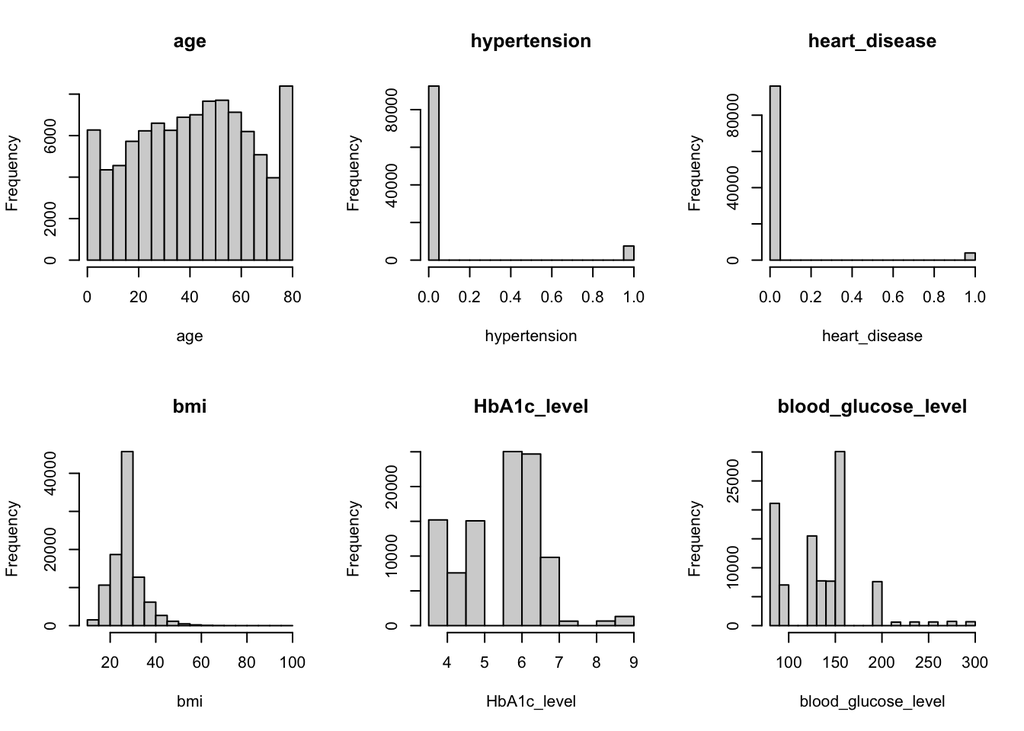

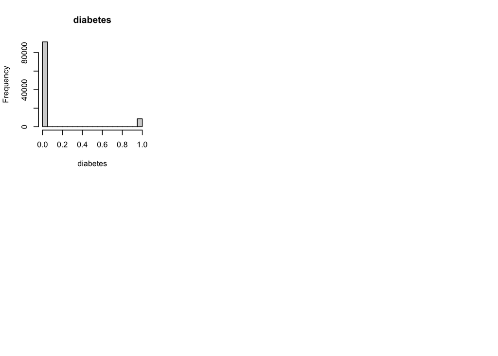

```r
par(mfrow = c(2, 3)) # Set the layout for the plot grid
for (var in numeric_vars) {
hist(diabetes[[var]], main = var, xlab = var)
}
```

#Switching to the categorical variables, showing the counts of each category of the two variables

```r
# Now Analyzing Categorical variables
for (col in names(categorical_diabetes)) {
cat("\n")
cat("Variable:", col, "\n")
analyze_categorical(diabetes[[col]])
}
```

```
##
## Variable: gender
##   Category Count
## 1   Female 58552
## 2     Male 41430
## 3    Other    18
##
## Variable: smoking_history
##      Category Count
## 5     No Info 35816
## 4       never 35095
## 3      former  9352
## 1     current  9286
## 6 not current  6447
## 2        ever  4004
```

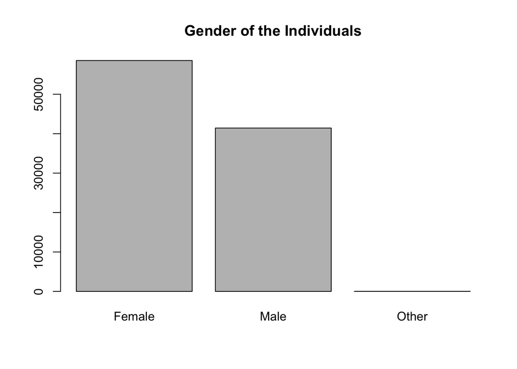

```r
# Create individual bar plots for each categorical variable
barplot(table(diabetes$gender), main = "Gender of the Individuals")
```

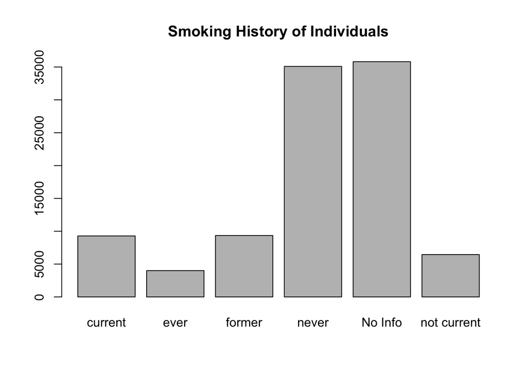

```r
barplot(table(diabetes$smoking_history), main = "Smoking History of Individuals")
```

```r
par(mfrow = c(1, 2))
```

```r
categorical_vars <- c("gender", "smoking_history")

chi_square_results <- list()
for (var in categorical_vars) {
print(var)
table_data <- table(diabetes[[var]], diabetes$diabetes)
print(table_data)
# Perform chi-square test
chi_result <- chisq.test(table_data)
# Print the results
print(chi_result)
}
```

```
## [1] "gender"
##
##              0     1
##   Female 54091  4461
##   Male   37391  4039
##   Other     18     0
```

```
##
##  Pearson's Chi-squared test
##
## data:  table_data
## X-squared = 143.22, df = 2, p-value < 2.2e-16
##
## [1] "smoking_history"
##
##                   0     1
##   current      8338   948
##   ever         3532   472
##   former       7762  1590
##   never       31749  3346
##   No Info     34362  1454
##   not current  5757   690
##
##  Pearson's Chi-squared test
##
## data:  table_data
## X-squared = 1956.1, df = 5, p-value < 2.2e-16
```

#Corrplot to help with feature selection

```r
#Compute correlation matrix
cor_matrix <- cor(numerical_diabetes)
print(cor_matrix)
```

```
##                           age hypertension heart_disease        bmi HbA1c_level
## age                 1.0000000   0.25117113    0.23335429 0.33739578  0.10135366
## hypertension        0.2511711   1.00000000    0.12126165 0.14766567  0.08093878
## heart_disease       0.2333543   0.12126165    1.00000000 0.06119782  0.06758883
## bmi                 0.3373958   0.14766567    0.06119782 1.00000000  0.08299716
## HbA1c_level         0.1013537   0.08093878    0.06758883 0.08299716  1.00000000
## blood_glucose_level 0.1106723   0.08442890    0.07006571 0.09126140  0.16673293
## diabetes            0.2580080   0.19782325    0.17172685 0.21435741  0.40066031
##                     blood_glucose_level  diabetes
## age                          0.11067227 0.2580080
## hypertension                 0.08442890 0.1978232
## heart_disease                0.07006571 0.1717268
## bmi                          0.09126140 0.2143574
## HbA1c_level                  0.16673293 0.4006603
## blood_glucose_level          1.00000000 0.4195580
## diabetes                     0.41955800 1.0000000
```

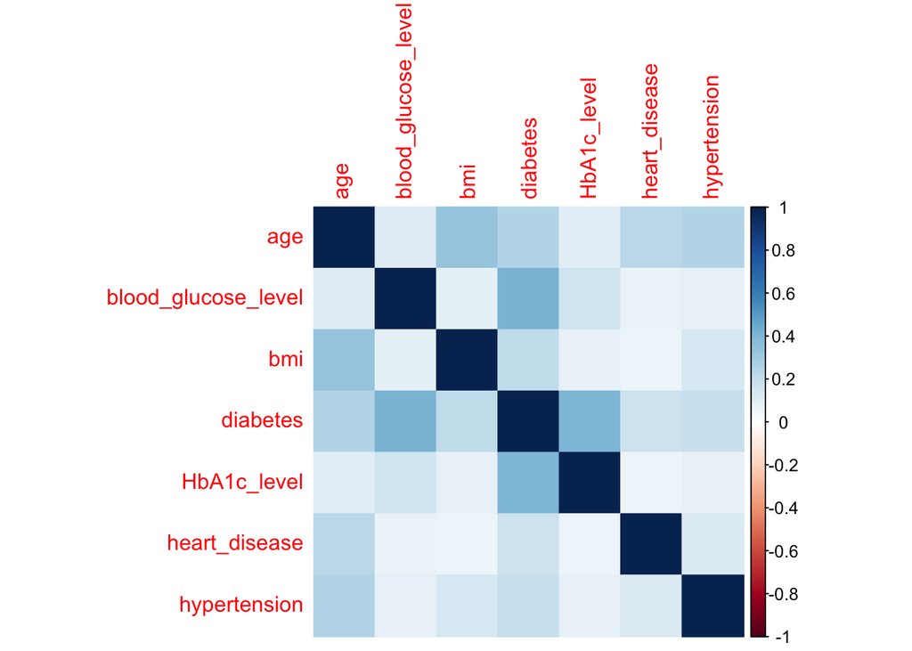

```r
#Create correlation heatmap
corrplot(cor_matrix, method = 'color',  order = 'alphabet' )
```

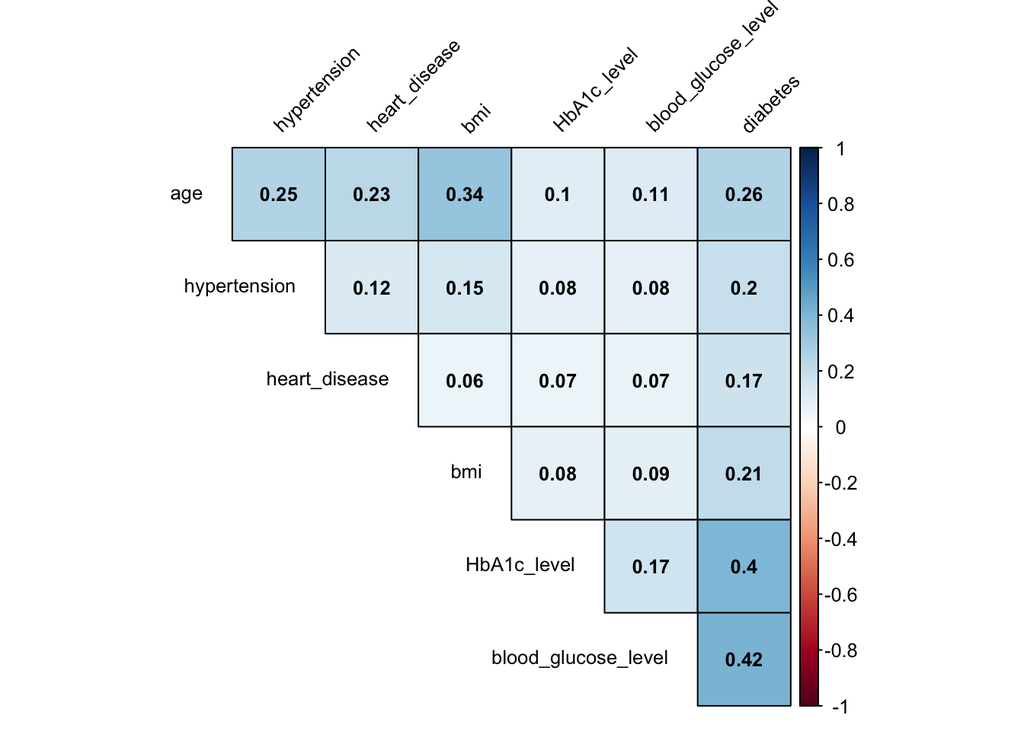

```r
corrplot(cor_matrix, method = "color", type = "upper", tl.col = "black",
tl.srt = 45, tl.cex = 0.8, tl.offset = 1, cl.lim = c(-1, 1),
addCoef.col = "black", number.cex = 0.8, number.digits = 2,
diag = FALSE, outline = TRUE)
```

#New corrplot that displays the categorical (gender and smoking history) as numerical also removed outliers from main set of data

```r
diabetes2 <- diabetes
diabetes2$smoking_history <- as.factor(diabetes2$smoking_history)
 groups <- dummyVars(~. , data = diabetes2)
 diabetes2 <- as.data.frame(predict(groups, diabetes2))
eliminatedBMI2 <- diabetes2$bmi > 50
diabetes2 <- subset(diabetes2, !eliminatedBMI2)

eliminatedHbA1c2 <- diabetes2$HbA1c_level > 8.2
diabetes2 <- subset(diabetes2, !eliminatedHbA1c2)

eliminatedBloodglucose2 <- diabetes2$blood_glucose_level > 201
diabetes2 <- subset(diabetes2, !eliminatedBloodglucose2)
```

```r
NormDiabetes <- diabetes2
write.xlsx(NormDiabetes, file = "NormalizedDiabetesData.xlsx", rowNames = FALSE)
```

```r
cor_matrix2 <- cor(diabetes2)
print(cor_matrix2)
```

```
##                             genderFemale   genderMale   genderOther
## genderFemale                 1.000000000 -0.999610232 -0.0163895450
## genderMale                  -0.999610232  1.000000000 -0.0115305275
## genderOther                 -0.016389545 -0.011530527  1.0000000000
## age                          0.036024154 -0.035830416 -0.0070262733
## hypertension                -0.014056762  0.014160444 -0.0036792207
## heart_disease               -0.076827552  0.076905457 -0.0026034580
## smoking_history.current     -0.025337240  0.025460922 -0.0043681171
## smoking_history.ever        -0.008981668  0.008950816  0.0011267718
## smoking_history.former      -0.044003529  0.044126693 -0.0043041949
## smoking_history.never        0.097835699 -0.097695444 -0.0052609864
## smoking_history.No Info     -0.057313254  0.057343900 -0.0009583435
## smoking_history.not current  0.010642391 -0.011242709  0.0214745753
## bmi                          0.015428026 -0.015457742  0.0010267698
## HbA1c_level                 -0.013727713  0.013745697 -0.0006107479
## blood_glucose_level         -0.006021095  0.005956644  0.0023229624
## diabetes                    -0.030758890  0.030844218 -0.0029812818
##                                      age hypertension heart_disease
## genderFemale                 0.036024154 -0.014056762  -0.076827552
## genderMale                  -0.035830416  0.014160444   0.076905457
## genderOther                 -0.007026273 -0.003679221  -0.002603458
## age                          1.000000000  0.244956282   0.226023442
## hypertension                 0.244956282  1.000000000   0.118887710
## heart_disease                0.226023442  0.118887710   1.000000000
## smoking_history.current      0.034902016  0.020938897   0.006737519
## smoking_history.ever         0.068387165  0.026350139   0.038761632
## smoking_history.former       0.214105702  0.080848769   0.090037187
## smoking_history.never        0.065723486  0.042785908  -0.030548889
## smoking_history.No Info     -0.274579164 -0.112099453  -0.046889495
## smoking_history.not current  0.067909251 -0.002445192   0.008158208
## bmi                          0.359065306  0.137560565   0.059914481
## HbA1c_level                  0.044705955  0.037987190   0.031283989
## blood_glucose_level          0.024514418  0.021189809   0.012249370
## diabetes                     0.192553870  0.152968993   0.135096264
##                             smoking_history.current smoking_history.ever
## genderFemale                          -0.0253372402         -0.008981668
## genderMale                             0.0254609223          0.008950816
## genderOther                           -0.0043681171          0.001126772
## age                                    0.0349020159          0.068387165
## hypertension                           0.0209388966          0.026350139
```

[output cut: 64 more lines]

```
## genderMale                   0.030844218
## genderOther                 -0.002981282
## age                          0.192553870
## hypertension                 0.152968993
## heart_disease                0.135096264
## smoking_history.current      0.011246819
## smoking_history.ever         0.024126219
## smoking_history.former       0.076367836
## smoking_history.never        0.022599902
## smoking_history.No Info     -0.090057027
## smoking_history.not current  0.011930887
## bmi                          0.158932462
## HbA1c_level                  0.245958020
## blood_glucose_level          0.115988044
## diabetes                     1.000000000
```

# New Heatmap that reveals correlation, both numerical and categorical

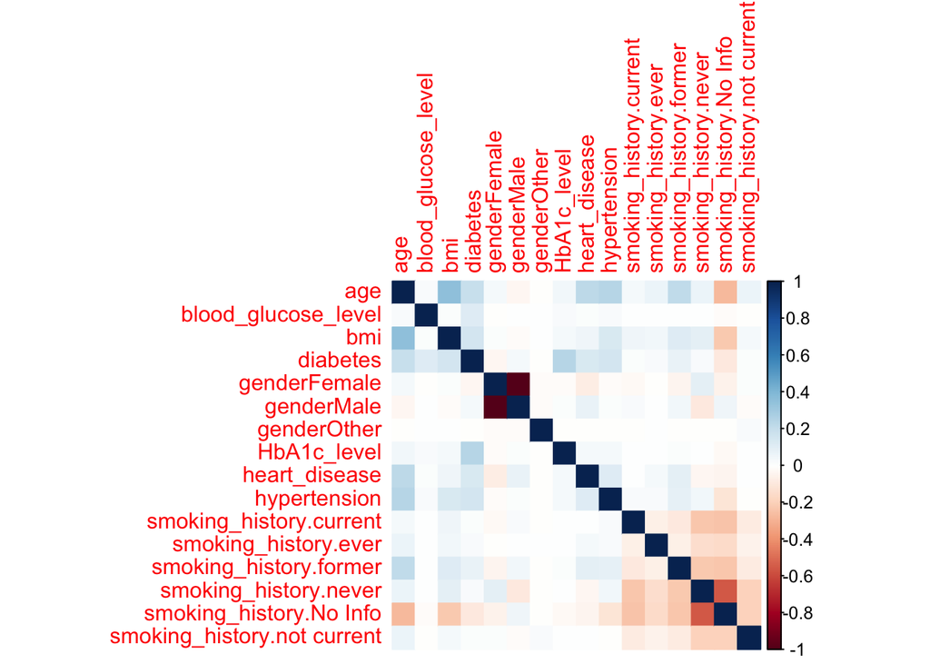

```r
corrplot(cor_matrix2, method = 'color',  order = 'alphabet' )
```

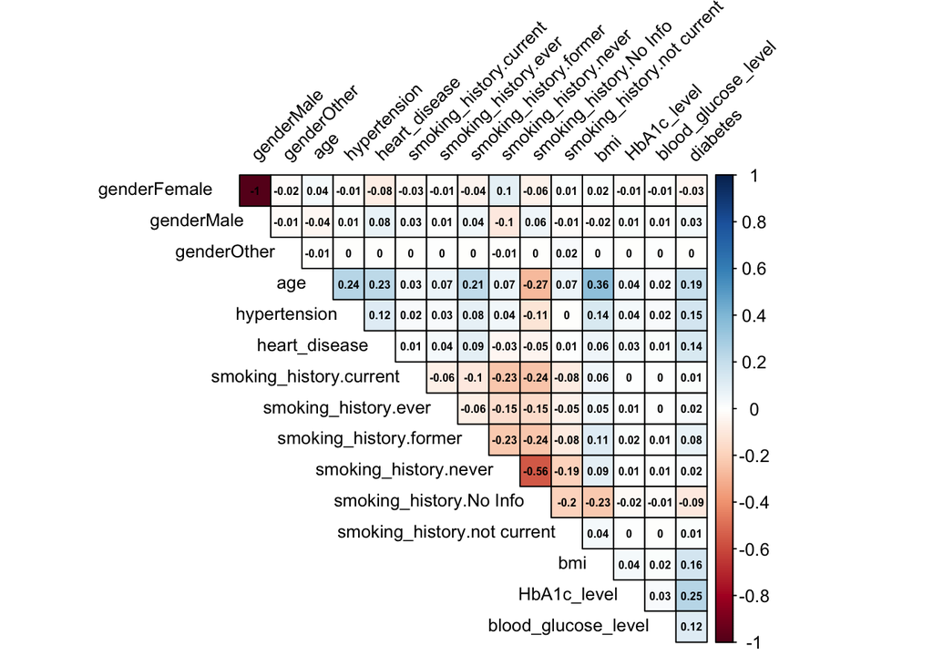

```r
corrplot(cor_matrix2, method = "color", type = "upper", tl.col = "black",
tl.srt = 45, tl.cex = 0.8, tl.offset = 1, cl.lim = c(-1, 1),
addCoef.col = "black", number.cex = 0.5, number.digits = 2,
diag = FALSE, outline = TRUE)
```

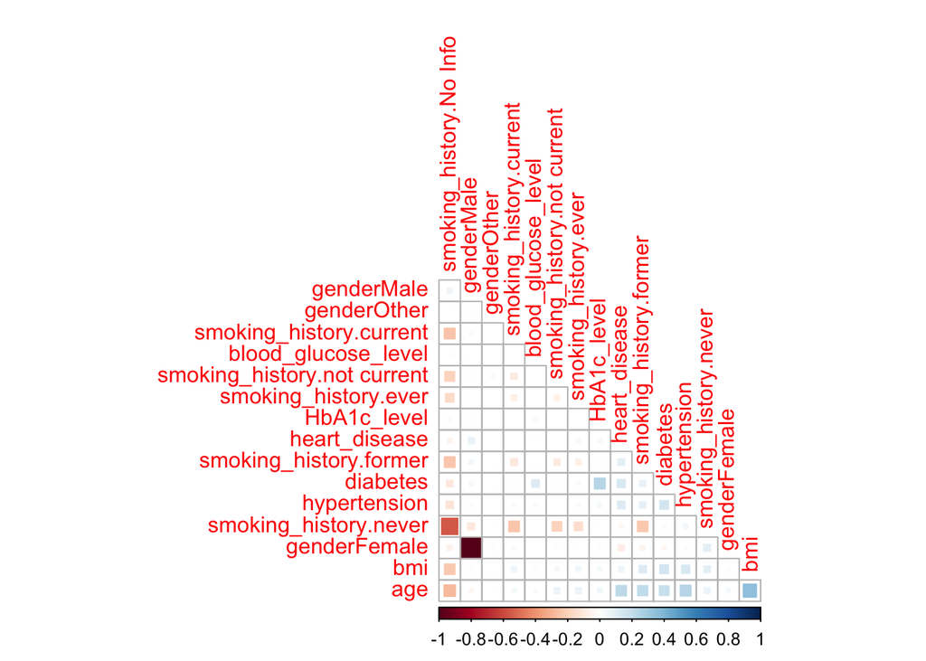

```r
corrplot(cor_matrix2, method = 'square', order = 'FPC', type = 'lower', diag = FALSE)
```

```r
scaledDiabetes <- scale(diabetes2)
scaledDiabetes <- as.data.frame(scaledDiabetes)
```

#Continued Feature Selection through stepwise regression which utilizes both foward and backward as methods

```r
full_model <- lm(scaledDiabetes$diabetes ~ ., data = scaledDiabetes)
both_step_model <- step(full_model, direction = "both")
```

```
## Start:  AIC=-13280.6
## scaledDiabetes$diabetes ~ genderFemale + genderMale + genderOther +
##     age + hypertension + heart_disease + smoking_history.current +
##     smoking_history.ever + smoking_history.former + smoking_history.never +
##     `smoking_history.No Info` + `smoking_history.not current` +
##     bmi + HbA1c_level + blood_glucose_level
##
##
## Step:  AIC=-13280.6
## scaledDiabetes$diabetes ~ genderFemale + genderMale + genderOther +
##     age + hypertension + heart_disease + smoking_history.current +
##     smoking_history.ever + smoking_history.former + smoking_history.never +
##     `smoking_history.No Info` + bmi + HbA1c_level + blood_glucose_level
##
##
## Step:  AIC=-13280.6
## scaledDiabetes$diabetes ~ genderFemale + genderMale + age + hypertension +
##     heart_disease + smoking_history.current + smoking_history.ever +
##     smoking_history.former + smoking_history.never + `smoking_history.No Info` +
##     bmi + HbA1c_level + blood_glucose_level
##
##                             Df Sum of Sq   RSS      AIC
## - smoking_history.current    1       0.1 82809 -13282.4
## - smoking_history.never      1       0.2 82809 -13282.4
## - genderFemale               1       0.2 82809 -13282.3
## - genderMale                 1       0.5 82809 -13282.0
## - smoking_history.ever       1       1.2 82810 -13281.2
## <none>                                   82809 -13280.6
## - `smoking_history.No Info`  1       6.1 82815 -13275.6
## - smoking_history.former     1      20.1 82829 -13259.5
## - heart_disease              1     623.0 83432 -12568.8
## - bmi                        1     651.2 83460 -12536.7
## - age                        1     677.1 83486 -12507.1
## - hypertension               1     745.5 83554 -12429.2
## - blood_glucose_level        1     989.3 83798 -12151.7
## - HbA1c_level                1    4938.5 87747  -7766.2
##
## Step:  AIC=-13282.43
## scaledDiabetes$diabetes ~ genderFemale + genderMale + age + hypertension +
##     heart_disease + smoking_history.ever + smoking_history.former +
```

[output cut: 73 more lines]

```
## + smoking_history.ever           1       1.4 82810 -13285.0
## + smoking_history.current        1       1.3 82810 -13284.8
## + smoking_history.never          1       0.2 82811 -13283.7
## + genderFemale                   1       0.2 82811 -13283.7
## + genderOther                    1       0.2 82811 -13283.7
## + `smoking_history.not current`  1       0.2 82811 -13283.6
## - `smoking_history.No Info`      1      29.7 82841 -13253.2
## - smoking_history.former         1      35.9 82847 -13246.1
## - genderMale                     1      56.0 82867 -13223.1
## - heart_disease                  1     624.8 83436 -12571.6
## - bmi                            1     651.2 83463 -12541.5
## - age                            1     680.8 83492 -12507.7
## - hypertension                   1     746.7 83558 -12432.6
## - blood_glucose_level            1     989.2 83801 -12156.6
## - HbA1c_level                    1    4939.4 87751  -7770.3
```

```r
summary(both_step_model)
```

```
##
## Call:
## lm(formula = scaledDiabetes$diabetes ~ genderMale + age + hypertension +
##     heart_disease + smoking_history.former + `smoking_history.No Info` +
##     bmi + HbA1c_level + blood_glucose_level, data = scaledDiabetes)
##
## Residuals:
##     Min      1Q  Median      3Q     Max
## -1.7971 -0.3953 -0.1747  0.0787  4.8624
##
## Coefficients:
##                             Estimate Std. Error t value Pr(>|t|)
## (Intercept)               -2.112e-15  3.022e-03   0.000        1
## genderMale                 2.443e-02  3.046e-03   8.021 1.06e-15 ***
## age                        9.753e-02  3.486e-03  27.979  < 2e-16 ***
## hypertension               9.183e-02  3.134e-03  29.301  < 2e-16 ***
## heart_disease              8.377e-02  3.126e-03  26.802  < 2e-16 ***
## smoking_history.former     2.032e-02  3.162e-03   6.425 1.32e-10 ***
## `smoking_history.No Info` -1.895e-02  3.243e-03  -5.844 5.12e-09 ***
## bmi                        8.971e-02  3.279e-03  27.363  < 2e-16 ***
## HbA1c_level                2.283e-01  3.029e-03  75.362  < 2e-16 ***
## blood_glucose_level        1.020e-01  3.025e-03  33.726  < 2e-16 ***
## ---
## Signif. codes:  0 '***' 0.001 '**' 0.01 '*' 0.05 '.' 0.1 ' ' 1
##
## Residual standard error: 0.9326 on 95219 degrees of freedom
## Multiple R-squared:  0.1304, Adjusted R-squared:  0.1303
## F-statistic:  1586 on 9 and 95219 DF,  p-value: < 2.2e-16
```

```r
scaledDiabetes2 <- scaledDiabetes
scaledDiabetes2$diabetes <- as.factor(scaledDiabetes2$diabetes)
pca_result <- prcomp(scaledDiabetes2[,-16])
summary(pca_result)
```

```
## Importance of components:
##                           PC1    PC2     PC3     PC4     PC5     PC6     PC7
## Standard deviation     1.4499 1.4027 1.17442 1.06865 1.04146 1.02501 1.01323
## Proportion of Variance 0.1401 0.1312 0.09195 0.07613 0.07231 0.07004 0.06844
## Cumulative Proportion  0.1401 0.2713 0.36325 0.43939 0.51170 0.58174 0.65018
##                            PC8     PC9    PC10    PC11    PC12   PC13      PC14
## Standard deviation     0.99716 0.99053 0.98278 0.94531 0.91617 0.7569 7.426e-13
## Proportion of Variance 0.06629 0.06541 0.06439 0.05957 0.05596 0.0382 0.000e+00
## Cumulative Proportion  0.71647 0.78188 0.84627 0.90585 0.96180 1.0000 1.000e+00
##                             PC15
## Standard deviation     6.028e-14
## Proportion of Variance 0.000e+00
## Cumulative Proportion  1.000e+00
```

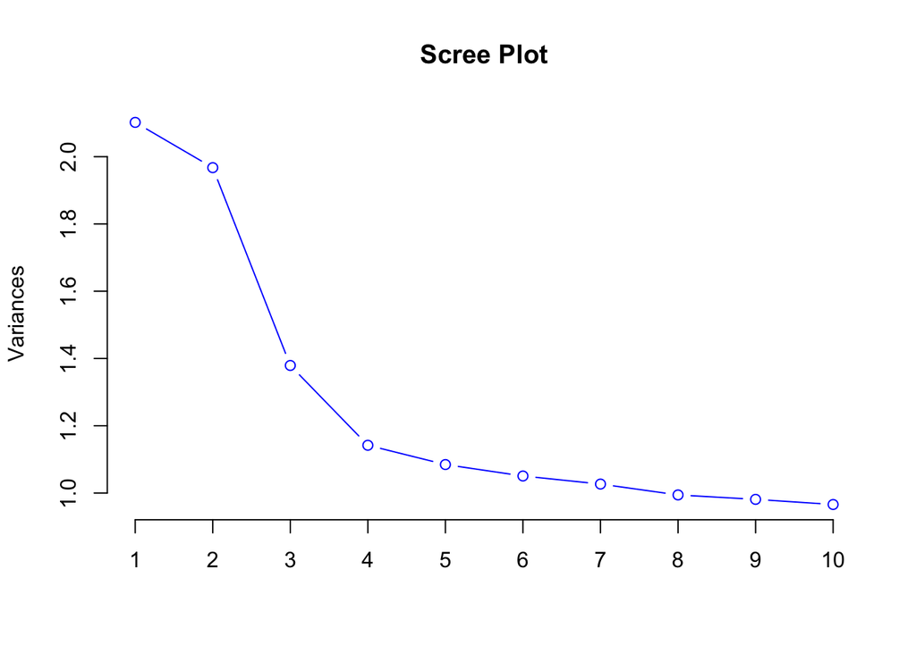

```r
plot(pca_result, type = "l", col = "blue", main = "Scree Plot")
```

```r
lmmodel <- lm(diabetes ~ bmi + age + heart_disease + hypertension + HbA1c_level + blood_glucose_level + genderFemale + genderMale + smoking_history.current + smoking_history.ever + smoking_history.former + smoking_history.never , data = scaledDiabetes)
summary(lmmodel)
```

```
##
## Call:
## lm(formula = diabetes ~ bmi + age + heart_disease + hypertension +
##     HbA1c_level + blood_glucose_level + genderFemale + genderMale +
##     smoking_history.current + smoking_history.ever + smoking_history.former +
##     smoking_history.never, data = scaledDiabetes)
##
## Residuals:
##     Min      1Q  Median      3Q     Max
## -1.7998 -0.3950 -0.1749  0.0789  4.8594
##
## Coefficients:
##                           Estimate Std. Error t value Pr(>|t|)
## (Intercept)             -2.079e-15  3.022e-03   0.000  1.00000
## bmi                      9.025e-02  3.273e-03  27.571  < 2e-16 ***
## age                      9.853e-02  3.466e-03  28.429  < 2e-16 ***
## heart_disease            8.364e-02  3.127e-03  26.746  < 2e-16 ***
## hypertension             9.177e-02  3.135e-03  29.268  < 2e-16 ***
## HbA1c_level              2.283e-01  3.029e-03  75.362  < 2e-16 ***
## blood_glucose_level      1.020e-01  3.025e-03  33.727  < 2e-16 ***
## genderFemale             5.049e-02  1.083e-01   0.466  0.64097
## genderMale               7.483e-02  1.083e-01   0.691  0.48942
## smoking_history.current  6.529e-03  3.204e-03   2.038  0.04159 *
## smoking_history.ever     1.011e-02  3.124e-03   3.238  0.00121 **
## smoking_history.former   2.972e-02  3.299e-03   9.008  < 2e-16 ***
## smoking_history.never    1.681e-02  3.361e-03   5.001 5.71e-07 ***
## ---
## Signif. codes:  0 '***' 0.001 '**' 0.01 '*' 0.05 '.' 0.1 ' ' 1
##
## Residual standard error: 0.9326 on 95216 degrees of freedom
## Multiple R-squared:  0.1304, Adjusted R-squared:  0.1302
## F-statistic:  1189 on 12 and 95216 DF,  p-value: < 2.2e-16
```

```r
my_lm_anova <- anova(lmmodel)
my_lm_anova
```

```
## Analysis of Variance Table
##
## Response: diabetes
##                            Df Sum Sq Mean Sq   F value    Pr(>F)
## bmi                         1   2405  2405.4 2765.6223 < 2.2e-16 ***
## age                         1   2007  2006.8 2307.3162 < 2.2e-16 ***
## heart_disease               1    883   882.8 1014.9711 < 2.2e-16 ***
## hypertension                1    908   907.6 1043.5613 < 2.2e-16 ***
## HbA1c_level                 1   5082  5081.7 5842.6966 < 2.2e-16 ***
## blood_glucose_level         1    995   994.7 1143.6289 < 2.2e-16 ***
## genderFemale                1     56    56.4   64.8507 8.172e-16 ***
## genderMale                  1      0     0.5    0.5659    0.4519
## smoking_history.current     1      0     0.2    0.2279    0.6331
## smoking_history.ever        1      2     2.0    2.2680    0.1321
## smoking_history.former      1     54    53.5   61.5635 4.331e-15 ***
## smoking_history.never       1     22    21.8   25.0125 5.706e-07 ***
## Residuals               95216  82815     0.9
## ---
## Signif. codes:  0 '***' 0.001 '**' 0.01 '*' 0.05 '.' 0.1 ' ' 1
```

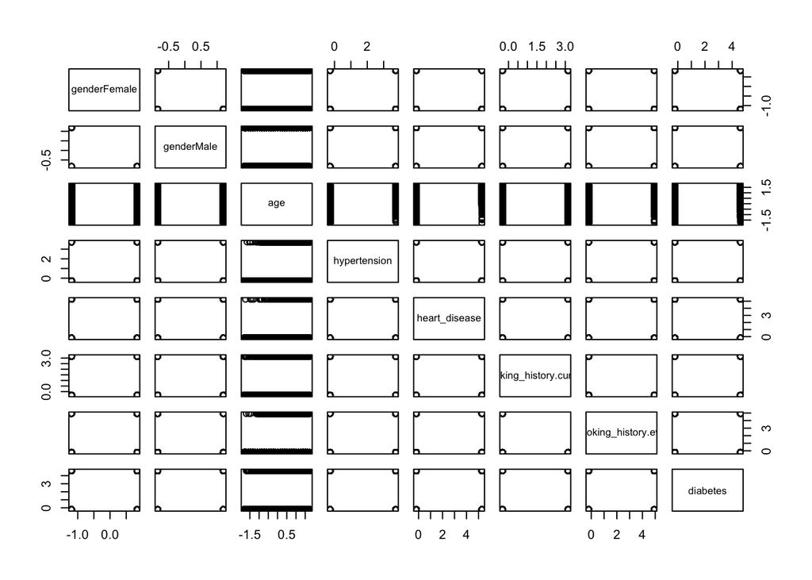

```r
pairs(scaledDiabetes[c(1,2,4,5,6,7,8,16)])
```

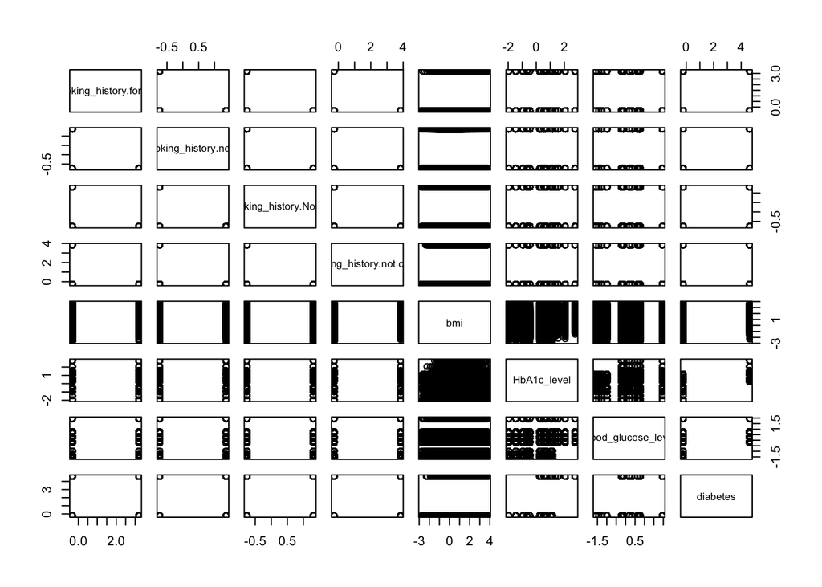

```r
pairs(scaledDiabetes[c(9,10,11,12,13,14,15,16)])
```

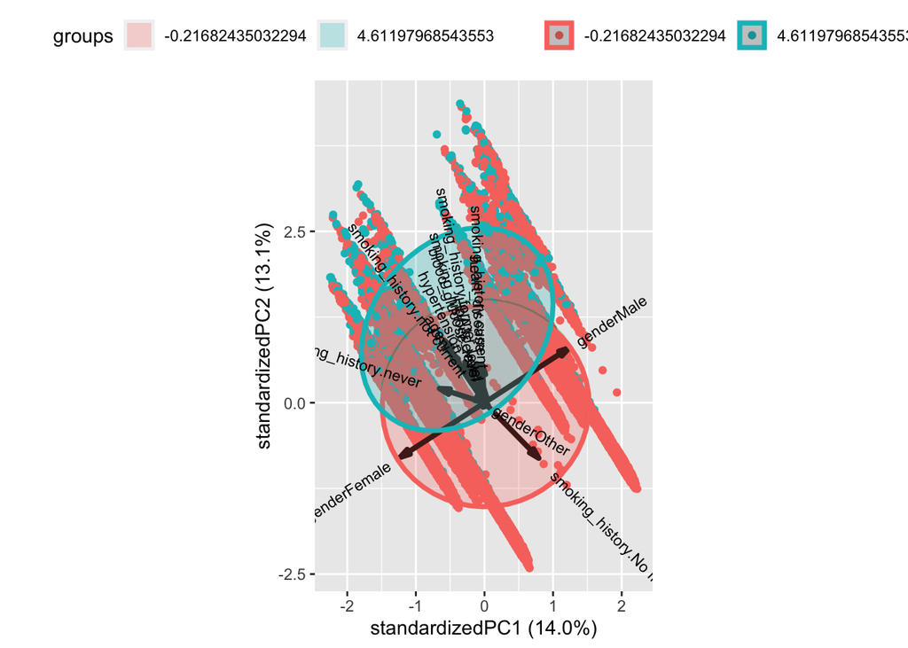

```r
##attributes(pca_result)

g <- ggbiplot(pca_result,
              groups = as.factor(scaledDiabetes$diabetes),
              ellipse = TRUE,
              circle = TRUE,
              ellipse.prob = 0.68)
g <- g + scale_color_discrete(name = '')
g <- g + theme(legend.direction = 'horizontal',
               legend.position = 'top')
print(g)
```